# Loan Default Prediction for Financial Risk Management

Bhavana Kappala

2025-02-01

## Objective:

The objective of this project is to develop and evaluate a predictive logistic regression model to accurately classify loan defaults based on various financial and demographic factors. The study aims to:

- Identify significant predictors influencing loan default by fitting multiple logistic regression models and performing stepwise selection to refine the model.
- Evaluate model performance using key statistical metrics, including Accuracy, Precision, Recall, F1-Score, and AUC, to ensure reliable classification of defaulters and non-defaulters.
- Determine the optimal decision threshold by analyzing the trade-off between Precision and Recall, optimizing the F1-Score, and selecting a cut-off that minimizes classification errors.
- Compare multiple candidate models based on cross-validation results to select the best-performing model for practical deployment.
- Assess model generalization by applying the final selected model to a test dataset, ensuring that it maintains high predictive accuracy in real-world scenarios.

## Introduction

- **Description of Data** This dataset is collected to analyze factors influencing loan defaults. It is intended for predictive modeling to assess the risk of default based on various customer attributes. The insights from this dataset can aid financial institutions in making informed lending decisions and mitigating risk.
  - *Itemized List of Feature Variables* -
1. Default (int, target variable) – Indicates whether a customer defaulted on a loan (0 = No, 1 = Yes).
2. Checking_amount (float) – Balance in the customer’s checking account.
3. Term (int) – Loan term in months.
4. Credit_score (int) – Customer’s credit score.
5. Gender (categorical) – Gender of the customer (Male/Female).
6. Marital_status (categorical) – Customer’s marital status (Single, Married, etc.).
7. Car_loan (int, boolean) – Whether the customer has a car loan (0 = No, 1 = Yes).
8. Personal_loan (int, boolean) – Whether the customer has a personal loan.
9. Home_loan (int, boolean) – Whether the customer has a home loan.
10. Education_loan (int, boolean) – Whether the customer has an education loan.
11. Emp_status (categorical) – Employment status (e.g., employed, unemployed).
12. Amount (int) – Loan amount requested.
13. Saving_amount (int) – Savings account balance.
14. Emp_duration (int) – Employment duration in months.
15. Age (int) – Age of the customer.
16. No_of_credit_acc (int) – Number of credits accounts the customer holds.

## Relationship between Features

- **Relationship Between Features**

This section explores relationships between key feature variables in the dataset, using appropriate visualizations to identify trends, correlations, and patterns. Understanding these relationships is essential for feature selection, engineering, and model development. We analyze:

- Relationships between two numerical features using scatter plots and correlation matrices. The scatter plot illustrates the relationship between Credit Score (x-axis) and Amount (y-axis). Here’s a summary of the observed trends:

Range of Credit Scores: The data spans credit scores approximately from 400 to 1000. Range of Amounts: The amounts vary from around 0 to 2500. Distribution: The data points are concentrated primarily in the middle range of credit scores (600–850) and amounts (500–1500). There is no clear linear correlation; instead, the data shows a diffuse, somewhat circular or elliptical pattern. Outliers: There are outliers present, with some extreme values of amounts (>2000) and some at lower credit scores. Conclusion: The relationship between Credit Score and Amount appears to be weak or nonexistent, as there is no discernible trend or pattern.

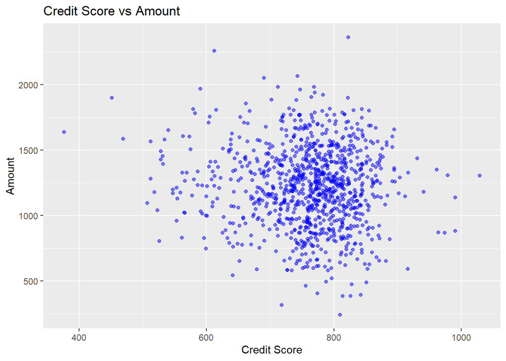

```r
# Scatter plot using ggplot2
ggplot(df, aes(x=Credit_score, y=Amount)) +
  geom_point(color="blue", alpha=0.5) +
  ggtitle("Credit Score vs Amount") +
  xlab("Credit Score") +
  ylab("Amount")
```

- Relationships between two categorical features using grouped bar charts or heatmaps.

The heatmap in the image visualizes the relationship between Default (presumably a binary variable indicating whether a person defaulted on a loan) and Employment Status (categorical: employed or unemployed). The color gradient represents the frequency of observations in each category, ranging from white (low frequency) to blue (high frequency).

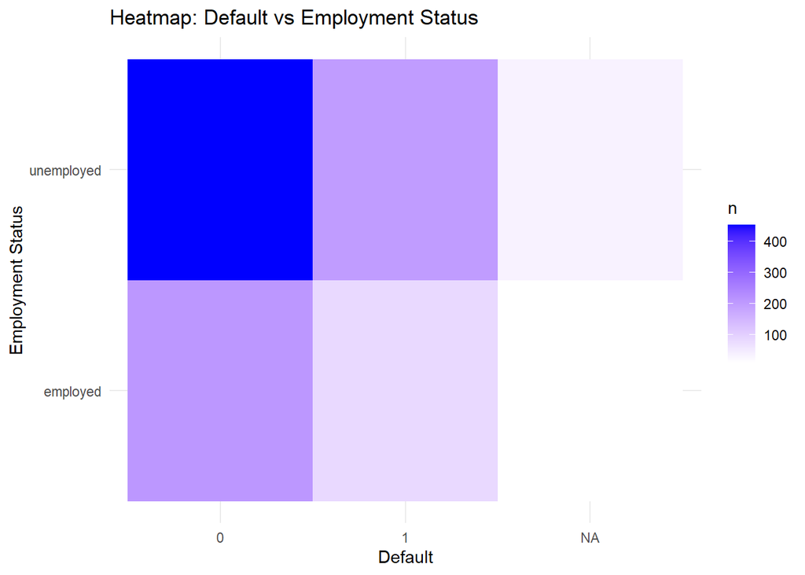

```r
heatmap_data <- df %>%
  count(Default, Emp_status)

# Heatmap: Relationship between Default and Employment Status
ggplot(heatmap_data, aes(x = Default, y = Emp_status, fill = n)) +
  geom_tile() +
  labs(title = "Heatmap: Default vs Employment Status",
       x = "Default", y = "Employment Status") +
  scale_fill_gradient(low = "white", high = "blue") +
  theme_minimal()
```

- Relationships between one numerical and one categorical feature using box plots. The box plot illustrates the relationship between Marital Status (categorical) and Credit Score (numerical).

Marital Status Categories:

There are at least two categories: “Married” and “Single.” Credit Score Distribution:

The median credit score is similar for both categories. “Married” individuals appear to have a slightly wider range of credit scores compared to “Single” individuals. Both categories have outliers, with a few credit scores extending below 600 and above 900. Variability:

The interquartile range (IQR) is slightly larger for “Married” individuals, indicating more variation in their credit scores compared to “Single.” Outliers:

Outliers are observed in both categories, mostly toward the lower end (below 600) and the higher end (above 900). Conclusion: There doesn’t appear to be a strong difference in the central tendency of credit scores between “Married” and “Single” individuals. However, variability in credit scores is slightly higher for “Married” individuals, with both groups exhibiting similar ranges and outliers.

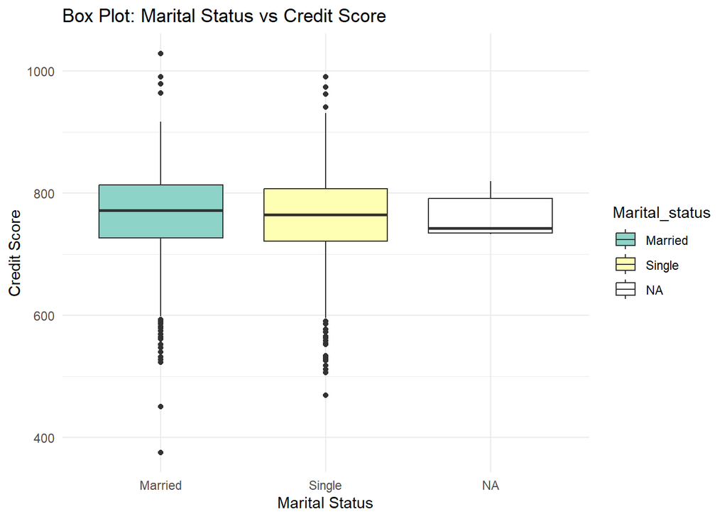

```r
# Box Plot: Relationship between Marital Status (Categorical) and Credit Score (Numerical)
ggplot(df, aes(x = Marital_status, y = Credit_score, fill = Marital_status)) +
  geom_boxplot() +
  labs(title = "Box Plot: Marital Status vs Credit Score",
       x = "Marital Status", y = "Credit Score") +
  theme_minimal() +
  scale_fill_brewer(palette = "Set3")
```

## Missing Value Imputation:

If the missing values are not handled properly, it could bias the analysis and affect machine learning models that require complete data.Ignoring these missing values or applying improper imputation could lead to data leakage or incorrect patterns during model training.

```r
# Function to count missing values in character variables, including empty cells

# Function to count missing values in all variables
count_missing_values <- function(data) {
  data %>%
    mutate(across(where(is.character), ~ na_if(., ""))) %>%
    summarise_all(~ sum(is.na(.))) %>%
    pivot_longer(everything(), names_to = "variable", values_to = "missing_count")
}
# Use the function
missing_values <- count_missing_values(df)

print(missing_values)
```

```
# A tibble: 16 × 2
   variable         missing_count
   <chr>                    <int>
 1 Default                     50
 2 Checking_amount              8
 3 Term                         0
 4 Credit_score                 0
 5 Gender                       0
 6 Marital_status               6
 7 Car_loan                     0
 8 Personal_loan                0
 9 Home_loan                    0
10 Education_loan               0
11 Emp_status                   0
12 Amount                       0
13 Saving_amount                0
14 Emp_duration                 0
15 Age                          0
16 No_of_credit_acc             0
```

## Replacement Imputation for Categorical Features:

Two possible replacement methods we can consider for imputing missing values:

- Replace missing values in categorical features with the mode of the corresponding variable.

```r
# Compute mode
mode_value <- df %>%
  count(Marital_status, sort = TRUE) %>%
  slice(1) %>%
  pull(Marital_status)

# Impute missing values
df$Marital_status[is.na(df$Marital_status)] <- mode_value

#Check
df %>%
  count(Marital_status, sort = TRUE) %>%
  print()
```

```
  Marital_status   n
1        Married 551
2         Single 449
```

```r
#print(sum(is.na(df$Marital_status)))
```

- Use the k-nearest neighbors (KNN) algorithm to impute missing values by assigning the value most common among the k-nearest neighbors surrounding the point with the missing data.

```r
# Perform KNN imputation after normalization and dummy encoding
df <- kNN(df, variable = "Marital_status", k = 15)

# Verify imputation
sum(is.na(df$Marital_status))
```

```
[1] 0
```

```r
table(df$Marital_status, useNA = "ifany")
```

```
Married  Single
    551     449
```

## Regression-based Imputation for Numerical Features:

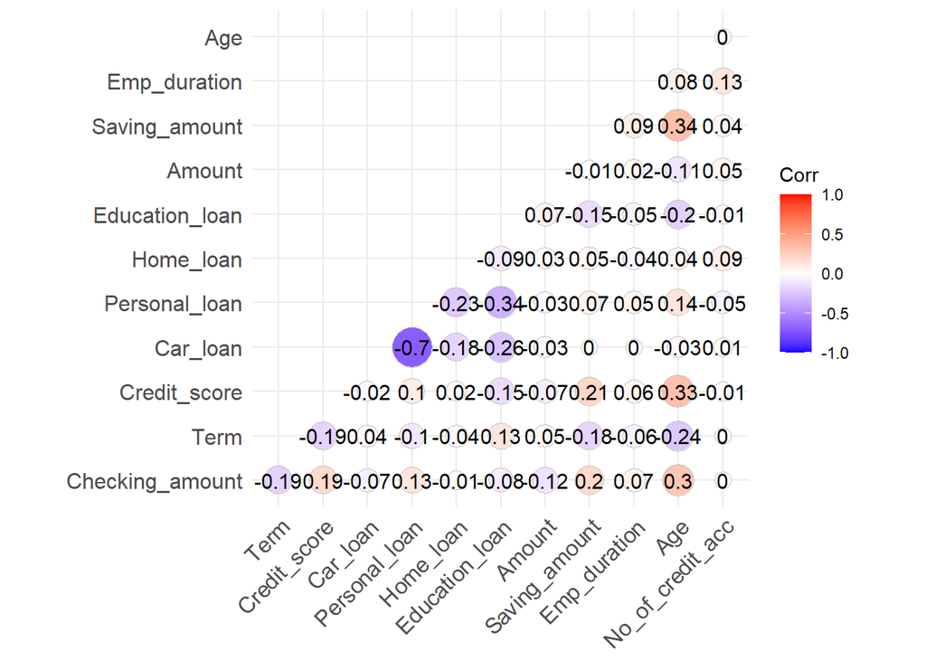

```r
df_num <- df
df_num$Default <- as.numeric(as.factor(df_num$Default))


numeric_features <- df %>% select_if(is.numeric)


# Compute correlation matrix
cor_matrix <- cor(numeric_features, use = "complete.obs")

# Plot heatmap
ggcorrplot(cor_matrix, method = "circle", type = "lower", lab = TRUE)
```

In the given plot, random regression imputation has been applied to predict missing values for the “Default” variable based on “Age.” The original data points (red) are compared with the imputed values (blue), illustrating how the regression model fills in missing entries while maintaining the overall data distribution. This approach is beneficial when there is a strong correlation between variables, ensuring more accurate and meaningful imputations.

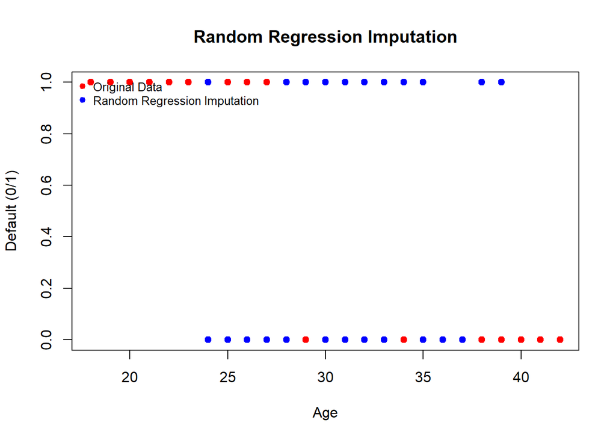

```r
# Create a new dataset with the imputed values (keeping original intact)
new_df <- df  # Copy the original dataset

z <- df$Age
y <- as.numeric(as.character(df$Default)) # Ensures 0 and 1 levels

# Split into observed and missing data
workSet <- df[!is.na(y) & !is.na(z), c("Default", "Age")]

newdata <- df[is.na(y), c("Age"), drop = FALSE]

workSet$Default <- as.numeric(as.character(workSet$Default))   # Converts to 0 and 1
new_df$Default <- as.numeric(as.character(new_df$Default))   # Converts to 0 and 1
# Fit logistic regression model
logit.mdl <- glm(Default ~ Age, data = workSet, family = binomial)
# Predict missing Default values
pred.y <- predict(logit.mdl, newdata = newdata, type = "response")

# Add random residual error to account for variability
set.seed(123)  # Ensure reproducibility
pred.resid <- rnorm(length(pred.y), mean = 0, sd = sd(residuals(logit.mdl)))
pred.y_rand <- pred.y + pred.resid  # Introduce variability

# Convert probabilities to binary classification
pred.y_bin <- ifelse(pred.y > 0.5, 1, 0)  # Regular regression imputation
pred.y_rand_bin <- ifelse(pred.y_rand > 0.5, 1, 0)  # Randomized regression imputation
new_df$Default[is.na(new_df$Default)] <- pred.y_rand_bin  # Impute into the new dataset

# Plot original data (default plotting color)
plot(workSet$Age, workSet$Default, main = "Random Regression Imputation",
     xlab = "Age", ylab = "Default (0/1)", col = "red", pch = 19)

# Plot Random regression imputation (blue points)
points(newdata$Age, pred.y_rand_bin, col = "blue", pch = 19)  # Random regression imputation in blue

# Add legend
legend("topleft", legend = c("Original Data", "Random Regression Imputation"),
       col = c("red", "blue"), pch = 19, bty = "n", cex = 0.8)
```

```r
new_df$Default <- factor(new_df$Default)

# Check the new dataset with imputed values
summary(new_df$Default)
```

```
  0   1
695 305
```

```r
#summary(df$Default)
# Use the function
missing_values <- count_missing_values(new_df)
print(missing_values)
```

```
# A tibble: 17 × 2
   variable           missing_count
   <chr>                      <int>
 1 Default                        0
 2 Checking_amount                8
 3 Term                           0
 4 Credit_score                   0
 5 Gender                         0
 6 Marital_status                 0
 7 Car_loan                       0
 8 Personal_loan                  0
 9 Home_loan                      0
10 Education_loan                 0
11 Emp_status                     0
12 Amount                         0
13 Saving_amount                  0
14 Emp_duration                   0
15 Age                            0
16 No_of_credit_acc               0
17 Marital_status_imp             0
```

## MICE:

The strong statistical significance of Age suggests it is a crucial predictor in the imputation process. The negative coefficient implies that as Age increases, the imputed values decrease. These results confirm that MICE effectively captures the relationship between variables, ensuring more accurate imputations for missing data.

```r
init <- mice(df, maxit = 0)  # Check initial imputation setup
methods <- init$method       # Extract the method template
methods["Default"] <- "logreg"  # Use logistic regression for binary variable
methods["Age"] <- "pmm"         # Predictive mean matching for Age (numeric)

imp <- mice(df, method = methods, maxit = 10, m = 7, print = FALSE)

imp_data <- complete(imp, action = 1L)[1:1000,]  # The default *action = 1L* returns the first
head(imp_data)
```

```
  Default Checking_amount Term Credit_score Gender Marital_status Car_loan
1       0             988   15          796 Female         Single        1
2       0             458   15          813 Female         Single        1
3       0             158   14          756 Female         Single        0
4       1             300   25          737 Female         Single        0
5       1              63   24          662 Female         Single        0
6       0            1071   20          828   Male        Married        1
  Personal_loan Home_loan Education_loan Emp_status Amount Saving_amount
1             0         0              0   employed   1536          3455
2             0         0              0   employed    947          3600
3             1         0              0   employed   1678          3093
4             0         0              1   employed   1804          2449
5             0         0              1 unemployed   1184          2867
6             0         0              0   employed    475          3282
  Emp_duration Age No_of_credit_acc Marital_status_imp
1           12  38                1              FALSE
2           25  36                1              FALSE
3           43  34                1              FALSE
4            0  29                1              FALSE
5            4  30                1              FALSE
6           12  32                2              FALSE
```

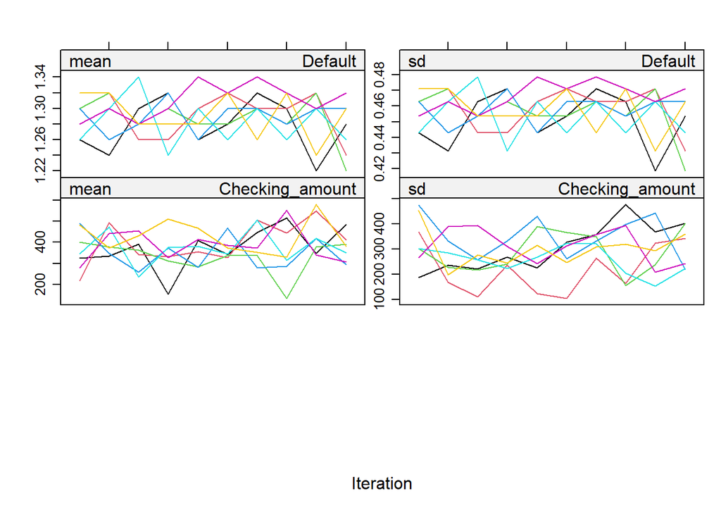

```r
plot(imp)
```

```r
# Function to count missing values in all variables
count_missing_values <- function(data) {
  data %>%
    mutate(across(where(is.character), ~ na_if(., ""))) %>%
    summarise_all(~ sum(is.na(.))) %>%
    pivot_longer(everything(), names_to = "variable", values_to = "missing_count")
}
# Use the function
missing_values <- count_missing_values(imp_data)
print(missing_values)
```

```
# A tibble: 17 × 2
   variable           missing_count
   <chr>                      <int>
 1 Default                        0
 2 Checking_amount                0
 3 Term                           0
 4 Credit_score                   0
 5 Gender                         0
 6 Marital_status                 0
 7 Car_loan                       0
 8 Personal_loan                  0
 9 Home_loan                      0
10 Education_loan                 0
11 Emp_status                     0
12 Amount                         0
13 Saving_amount                  0
14 Emp_duration                   0
15 Age                            0
16 No_of_credit_acc               0
17 Marital_status_imp             0
```

```r
model_3 <- with(imp, glm(Default ~ Age, family = binomial))  # The statistical model to assess
                                             # the relationship between *Ozone*
                                             # and *Wind* and *Temp*.
summary.stats = summary(model_3)               # display the regression results of
                                             # individual imputed data set.
#summary.stats
summary(pool(model_3))
```

```
         term   estimate  std.error statistic       df      p.value
1 (Intercept) 18.7450581 1.27984820  14.64631 913.9592 8.643868e-44
2         Age -0.6527812 0.04327903 -15.08308 902.9110 5.154104e-46
```

## Checking for Skewness:

No of Credit Accounts is one of the highly skewed variables in the dataset. Skewness is identified using skewness function on all numeric features of the dataset.

```r
df$Checking_amount <- as.numeric(df$Checking_amount)
df$Amount <- as.numeric(df$Amount)
df$Saving_amount <-as.numeric(df$Saving_amount)
#library(e1071)  # For skewness function
#library(ggplot2)  # For visualization

# Select only numeric columns
numeric_vars <- df[, sapply(df, is.numeric)]
# Compute skewness for each numeric variable
skewness_values <- sapply(numeric_vars, skewness, na.rm = TRUE)

# Identify highly skewed variables
skewed_vars <- names(skewness_values[abs(skewness_values) > 1])

# Print results
print("Skewness values:")
```

```
[1] "Skewness values:"
```

```r
print(skewness_values)
```

```
 Checking_amount             Term     Credit_score         Car_loan
      0.13871000       0.03449041      -0.80570959       0.61426542
   Personal_loan        Home_loan   Education_loan           Amount
      0.10398472       3.85639213       2.45693948      -0.01302117
   Saving_amount     Emp_duration              Age No_of_credit_acc
     -0.15512342       0.38470134      -0.24434353       1.42833228
```

```r
print("Highly skewed variables:")
```

```
[1] "Highly skewed variables:"
```

```r
print(skewed_vars)
```

```
[1] "Home_loan"        "Education_loan"   "No_of_credit_acc"
```

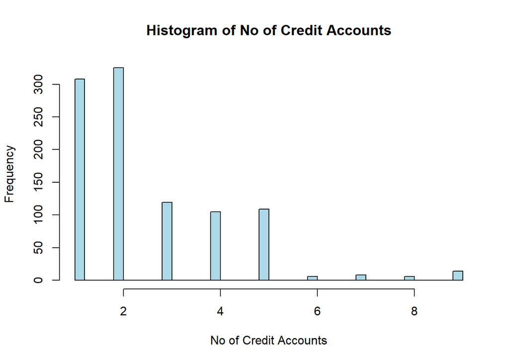

```r
# Create a histogram for Skewed Numeric Variable - No of Credit Accounts
hist(numeric_vars$No_of_credit_acc,
     main = "Histogram of No of Credit Accounts",
     xlab = "No of Credit Accounts",
     col = "lightblue",
     breaks = 30)
```

## Feature Transformation:

The below R code preprocesses data and builds logistic regression models to predict Default (a binary outcome). It begins with feature scaling, where normalization scales No_of_credit_acc between 0 and 1, standardization transforms it to have a mean of 0 and standard deviation of 1, and a log transformation (log(x+1)) reduces skewness. Categorical variables such as Gender, Marital_status, and Emp_status are then converted into factors for proper model interpretation.

```r
# Normalization
normalize <- function(x) {
  return((x - min(x)) / (max(x) - min(x)))
}
df$No_CreditAcc_normalized <- normalize(df$No_of_credit_acc)

# Standardization
standardize <- function(x) {
  return((x - mean(x)) / sd(x))
}
df$No_CreditAcc_standardized <- standardize(df$No_of_credit_acc)
df$No_of_credit_acc_transformed <- log(df$No_of_credit_acc + 1)  # Log transformation

df$Gender <- as.factor(df$Gender)
df$Marital_status <- as.factor(df$Marital_status)
df$Emp_status <- as.factor(df$Emp_status)

new_df <- df[, c("Default","Checking_amount","Term",    "Credit_score"  ,"Gender",  "Marital_status" ,  "Car_loan", "Personal_loan",    "Home_loan",    "Education_loan",   "Emp_status",   "Amount",   "Saving_amount",    "Emp_duration",     "Age",  "No_of_credit_acc_transformed" )]

str(new_df)
```

```
'data.frame':   1000 obs. of  16 variables:
 $ Default                     : Factor w/ 2 levels "0","1": 1 1 1 2 2 1 1 1 1 2 ...
 $ Checking_amount             : num  988 458 158 300 63 ...
 $ Term                        : int  15 15 14 25 24 20 13 16 20 19 ...
 $ Credit_score                : int  796 813 756 737 662 828 856 763 778 649 ...
 $ Gender                      : Factor w/ 2 levels "Female","Male": 1 1 1 1 1 2 2 1 1 2 ...
 $ Marital_status              : Factor w/ 2 levels "Married","Single": 2 2 2 2 2 1 2 2 2 1 ...
 $ Car_loan                    : int  1 1 0 0 0 1 1 1 1 1 ...
 $ Personal_loan               : int  0 0 1 0 0 0 0 0 0 0 ...
 $ Home_loan                   : int  0 0 0 0 0 0 0 0 0 0 ...
 $ Education_loan              : int  0 0 0 1 1 0 0 0 0 0 ...
 $ Emp_status                  : Factor w/ 2 levels "employed","unemployed": 1 1 1 1 2 1 1 1 2 1 ...
 $ Amount                      : num  1536 947 1678 1804 1184 ...
 $ Saving_amount               : num  3455 3600 3093 2449 2867 ...
 $ Emp_duration                : int  12 25 43 0 4 12 11 12 12 0 ...
 $ Age                         : int  38 36 34 29 30 32 38 36 36 29 ...
 $ No_of_credit_acc_transformed: num  0.693 0.693 0.693 0.693 0.693 ...
```

```r
#full_model <- glm(Default ~ ., data = new_df, family = binomial)
#summary(full_model)

#final_model <- glm(Default ~ Checking_amount+Term+Credit_score+Age, data = new_df, family = binomial )
#summary(final_model)
```

## Principal Component Analysis:

The images and R code illustrate a Principal Component Analysis (PCA) performed on a preprocessed dataset. Categorical variables were converted to numeric using one-hot encoding, missing values were handled, and data was standardized before applying PCA. The Scree Plot shows the variance explained by each component, helping determine the optimal number of principal components. The scatter plot of the first two principal components visualizes the data distribution, revealing potential clusters or patterns. This analysis helps reduce dimensionality while preserving key information in the dataset.

Based on our scree plot and variance explained by various principal components, it is observed that PC01 and PC02 explain about 37% of total variability, suggesting that dimensionality cannot be reduced effectively without losing much information based on recommended 70-80%. Clustered components on the scatter plot suggest that the underlying structure is well captured by the principal component analysis.

Based on our Scree Plot, it would be beneficial to retain PC1, PC2, PC3, PC4, PC5, PC6 and PC7 which explains about 74% of total variance.

```r
# Step 1: Convert categorical variables to numeric using one-hot encoding
df_numeric <- df %>%
 mutate(across(c(Gender, Marital_status, Emp_status), as.factor)) %>%  # Convert to factors
   dummyVars(~ ., data = .) %>%
  predict(newdata = df) %>%
   as.data.frame()

 # Step 2: Select only numeric features
 numeric_data <- df_numeric %>% select_if(is.numeric)

 # Step 3: Handle missing and infinite values
 numeric_data[is.na(numeric_data)] <- 0   # Replace NAs with 0 (or use median imputation)

 constant_cols <- apply(numeric_data, 2, function(col) var(col, na.rm = TRUE) == 0)
numeric_data <- numeric_data[, !constant_cols]


 # Step 4: Standardize the data (only after handling missing values)
 scaled_data <- scale(numeric_data)

 # Step 5: Perform PCA
 pca_result <- prcomp(scaled_data, center = TRUE, scale = TRUE)

 summary(pca_result)
```

```
Importance of components:
                          PC1    PC2    PC3     PC4     PC5     PC6     PC7
Standard deviation     2.1492 1.9052 1.8029 1.32287 1.27832 1.07472 1.02233
Proportion of Variance 0.2008 0.1578 0.1413 0.07609 0.07105 0.05022 0.04544
Cumulative Proportion  0.2008 0.3587 0.5000 0.57607 0.64711 0.69733 0.74277
                           PC8     PC9    PC10    PC11    PC12    PC13    PC14
Standard deviation     1.00157 0.92775 0.91072 0.89143 0.86445 0.79162 0.70378
Proportion of Variance 0.04362 0.03742 0.03606 0.03455 0.03249 0.02725 0.02153
Cumulative Proportion  0.78639 0.82381 0.85987 0.89442 0.92691 0.95416 0.97569
                         PC15   PC16    PC17    PC18      PC19      PC20
Standard deviation     0.6344 0.3251 0.20743 0.08831 1.148e-15 9.202e-16
Proportion of Variance 0.0175 0.0046 0.00187 0.00034 0.000e+00 0.000e+00
Cumulative Proportion  0.9932 0.9978 0.99966 1.00000 1.000e+00 1.000e+00
                            PC21      PC22      PC23
Standard deviation     7.322e-16 5.461e-16 1.823e-16
Proportion of Variance 0.000e+00 0.000e+00 0.000e+00
Cumulative Proportion  1.000e+00 1.000e+00 1.000e+00
```

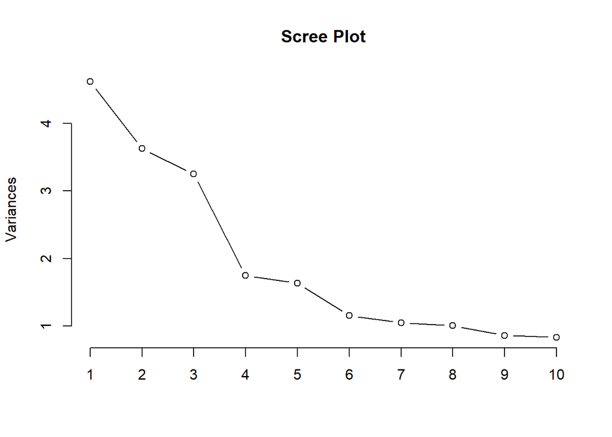

```r
 # Step 6: Scree Plot (to decide number of components to keep)
 screeplot(pca_result, type = "lines", main = "Scree Plot")
```

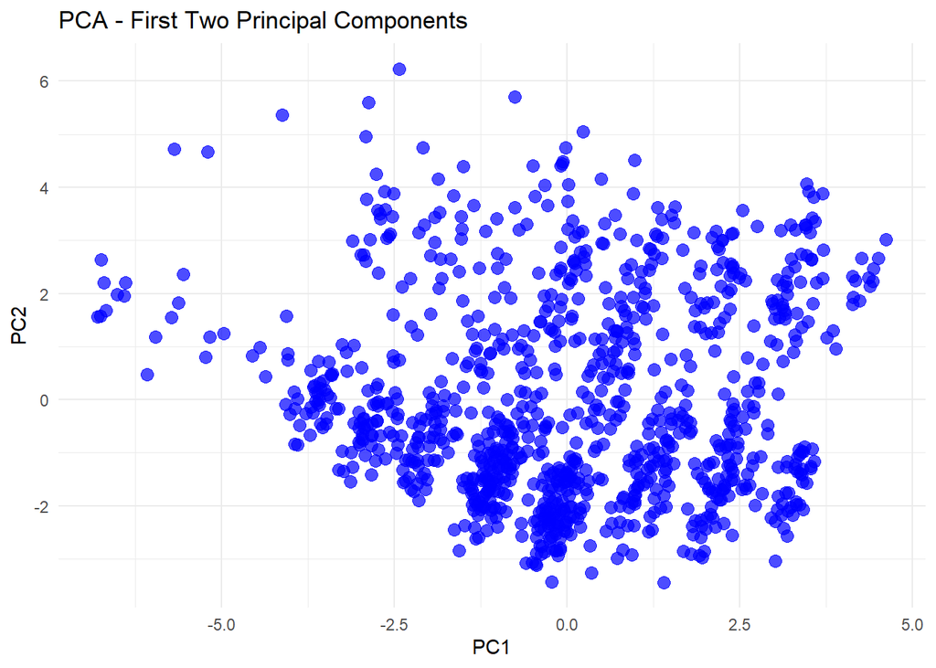

```r
 # Step 7: Biplot (PCA visualization)
# biplot(pca_result, scale = 0)

 # Step 8: Scatter plot of first two principal components
 pca_df <- as.data.frame(pca_result$x)
 ggplot(pca_df, aes(x = PC1, y = PC2)) +
   geom_point(size = 3, alpha = 0.7, color = "blue") +
 labs(title = "PCA - First Two Principal Components") +
   theme_minimal()
```

```r
#variance_explained <- summary(pca_result)$importance[2, ]  # Extract proportion of variance explained
#pca_result$rotation
#reduced_data <- pca_result$x[, 1:7]
#reduced_data <- cbind(reduced_data, Target = df$Default)
#cor(pca_result$x)

#summary(reduced_data)
```

## Candidate model selection through Regression Analysis (Stepwise feature Selection(backward & forward) and glm)

*Working Data Set and Practical Question:*

The final dataset was generated using the Multiple Imputation by Chained Equations (MICE) procedure, a statistical method employed to handle missing data in a comprehensive and robust manner. The resulting final dataset is one in which missing values are replaced with plausible estimates, ensuring that the dataset can be used for further analysis without introducing significant bias, while preserving the inherent variability in the data

*Data Splitting:* Final Dataset imp_data has been split into training, validation and testing datasets.

```r
# Assuming imp_data is your full dataset
set.seed(123)  # For reproducibility

# Split the data into training (70%), test (30%)
train.ID = sample(1:dim(imp_data)[1], 0.8 * dim(imp_data)[1], replace = FALSE)
train_data = imp_data[train.ID, ]
test_set = imp_data[-train.ID, ]


# Step 3: Check the size of each set to ensure the data has been split correctly
cat("Training data size:", nrow(train_data), "\n")
```

```
Training data size: 800
```

```r
cat("Test data size:", nrow(test_set), "\n")
```

```
Test data size: 200
```

## Model Selection via 10-fold Cross-Validation:

*Model 1 : Default = Checking_amount + Term + Credit_score + Car_loan + Personal_loan1 + Home_loan + Saving_amount + Age*

*Model 2 : Default = Age + Saving_amount + Checking_amount + Credit_score + Home_loan + Term + Personal_loan + Education_loan*

*Model 3 : Default = Includes Checking Amount, Age, Term, Credit Score, Saving Amount*

*Model 5 : Default = Age + Saving_amount + Checking_amount + Education_loan*

Six candidate models were evaluated, each developed using a different subset of predictors. The models were evaluated based on their AUC (Area Under the Curve), Precision, Recall, and F1-Score to assess their ability to accurately predict loan defaults.

```r
# Define number of folds for cross-validation (10-fold)
k = 10

# Initialize vectors to store AUC, Precision, Recall, and F1-Score for each model
AUC.m1 = NULL
AUC.m2 = NULL
AUC.m3 = NULL
AUC.m4 = NULL
AUC.m5 = NULL
AUC.m6 = NULL


precision.m1 = NULL
precision.m2 = NULL
precision.m3 = NULL
precision.m4 = NULL
precision.m5 = NULL
precision.m6 = NULL


recall.m1 = NULL
recall.m2 = NULL
recall.m3 = NULL
recall.m4 = NULL
recall.m5 = NULL
recall.m6 = NULL

f1.m1 = NULL
f1.m2 = NULL
f1.m3 = NULL
f1.m4 = NULL
f1.m5 = NULL
f1.m6 = NULL

# Define the thresholds you want to test (e.g., from 0.1 to 0.9)
thresholds = seq(0.1, 0.9, by = 0.05)

# Loop over the folds
for (i in 1:k) {
  # Define the observation IDs for the i-th fold validation set
  fold_size = ceiling(nrow(train_data) / k)
  valid.ID = ((i - 1) * fold_size + 1):(i * fold_size)
  valid_set = train_data[valid.ID, ]
  train_set = train_data[-valid.ID, ]

  # Fit models using the training subset (train_set)
  M01 = glm(Default ~ Checking_amount + Term + Credit_score + Car_loan + Personal_loan + Home_loan + Saving_amount + Age, family = binomial, data = train_set) #Model from backward

  M02 = glm(Default ~ Age + Saving_amount + Checking_amount + Credit_score + Home_loan + Term + Personal_loan + Education_loan, family = binomial, data = train_set) #Model from forward

  M03 = glm(Default ~ Checking_amount + Age + Term + Credit_score + Saving_amount, family = binomial, data = train_set) #Model from glm

 M04 = glm(Default ~ Age + Saving_amount + Credit_score + Checking_amount + Education_loan, family = binomial, data = train_set) #Model from backward

  M05 = glm(Default ~ Age + Saving_amount + Checking_amount + Education_loan, family = binomial, data = train_set) #Model from backward

  M06 = glm(Default ~ Checking_amount + Credit_score + Car_loan + Education_loan + Saving_amount + Age, family = binomial, data = train_set) #Model from backward

  # Predicting Default using the models on the validation set (valid_set)
  predM01 = predict(M01, newdata = valid_set, type = "response")
  predM02 = predict(M02, newdata = valid_set, type = "response")
  predM03 = predict(M03, newdata = valid_set, type = "response")
  predM04 = predict(M04, newdata = valid_set, type = "response")
  predM05 = predict(M05, newdata = valid_set, type = "response")
  predM06 = predict(M06, newdata = valid_set, type = "response")


  # Loop over thresholds to calculate Precision, Recall, and F1-Score
  for (thresh in thresholds) {
    # Convert probabilities to binary predictions using the current threshold
    pred_labels_M01 = ifelse(predM01 > thresh, 1, 0)
    pred_labels_M02 = ifelse(predM02 > thresh, 1, 0)
    pred_labels_M03 = ifelse(predM03 > thresh, 1, 0)
    pred_labels_M04 = ifelse(predM04 > thresh, 1, 0)
    pred_labels_M05 = ifelse(predM05 > thresh, 1, 0)
    pred_labels_M06 = ifelse(predM06 > thresh, 1, 0)


    # Calculate confusion matrix for each model
    cm_M01 = confusionMatrix(factor(pred_labels_M01), factor(valid_set$Default))
    cm_M02 = confusionMatrix(factor(pred_labels_M02), factor(valid_set$Default))
    cm_M03 = confusionMatrix(factor(pred_labels_M03), factor(valid_set$Default))
    cm_M04 = confusionMatrix(factor(pred_labels_M04), factor(valid_set$Default))
    cm_M05 = confusionMatrix(factor(pred_labels_M05), factor(valid_set$Default))
    cm_M06 = confusionMatrix(factor(pred_labels_M06), factor(valid_set$Default))

    # Calculate Precision, Recall, and F1-Score for each model at this threshold
    precision.m1[i] = cm_M01$byClass['Pos Pred Value']
    precision.m2[i] = cm_M02$byClass['Pos Pred Value']
    precision.m3[i] = cm_M03$byClass['Pos Pred Value']
    precision.m4[i] = cm_M04$byClass['Pos Pred Value']
    precision.m5[i] = cm_M05$byClass['Pos Pred Value']
    precision.m6[i] = cm_M06$byClass['Pos Pred Value']


    recall.m1[i] = cm_M01$byClass['Sensitivity']
    recall.m2[i] = cm_M02$byClass['Sensitivity']
    recall.m3[i] = cm_M03$byClass['Sensitivity']
    recall.m4[i] = cm_M04$byClass['Sensitivity']
    recall.m5[i] = cm_M05$byClass['Sensitivity']
    recall.m6[i] = cm_M06$byClass['Sensitivity']

    f1.m1[i] = cm_M01$byClass['F1']
    f1.m2[i] = cm_M02$byClass['F1']
    f1.m3[i] = cm_M03$byClass['F1']
    f1.m4[i] = cm_M04$byClass['F1']
    f1.m5[i] = cm_M05$byClass['F1']
    f1.m6[i] = cm_M06$byClass['F1']

  }

  # Calculate AUC for each model using the validation set
  roc_M01 = roc(valid_set$Default, predM01)
  roc_M02 = roc(valid_set$Default, predM02)
  roc_M03 = roc(valid_set$Default, predM03)
  roc_M04 = roc(valid_set$Default, predM04)
  roc_M05 = roc(valid_set$Default, predM05)
  roc_M06 = roc(valid_set$Default, predM06)

  # Store the AUC values for each fold
  AUC.m1[i] = auc(roc_M01)
  AUC.m2[i] = auc(roc_M02)
  AUC.m3[i] = auc(roc_M03)
  AUC.m4[i] = auc(roc_M04)
  AUC.m5[i] = auc(roc_M05)
  AUC.m6[i] = auc(roc_M06)

}

# Calculate the average AUC, Precision, Recall, and F1-Score for each model across all folds
mean_AUC_m1 = mean(AUC.m1)
mean_AUC_m2 = mean(AUC.m2)
mean_AUC_m3 = mean(AUC.m3)
mean_AUC_m4 = mean(AUC.m4)
mean_AUC_m5 = mean(AUC.m5)
mean_AUC_m6 = mean(AUC.m6)


mean_precision_m1 = mean(precision.m1)
mean_precision_m2 = mean(precision.m2)
mean_precision_m3 = mean(precision.m3)
mean_precision_m4 = mean(precision.m4)
mean_precision_m5 = mean(precision.m5)
mean_precision_m6 = mean(precision.m6)

mean_recall_m1 = mean(recall.m1)
mean_recall_m2 = mean(recall.m2)
mean_recall_m3 = mean(recall.m3)
mean_recall_m4 = mean(recall.m4)
mean_recall_m5 = mean(recall.m5)
mean_recall_m6 = mean(recall.m6)


mean_f1_m1 = mean(f1.m1)
mean_f1_m2 = mean(f1.m2)
mean_f1_m3 = mean(f1.m3)
mean_f1_m4 = mean(f1.m4)
mean_f1_m5 = mean(f1.m5)
mean_f1_m6 = mean(f1.m6)

# Create a data frame with all the performance metrics
results_table <- data.frame(
  Model = paste("Model", 1:6),
  AUC = c(mean_AUC_m1, mean_AUC_m2, mean_AUC_m3, mean_AUC_m4, mean_AUC_m5, mean_AUC_m6),
  Precision = c(mean_precision_m1, mean_precision_m2, mean_precision_m3, mean_precision_m4, mean_precision_m5, mean_precision_m6),
  Recall = c(mean_recall_m1, mean_recall_m2, mean_recall_m3, mean_recall_m4, mean_recall_m5, mean_recall_m6),
  F1_Score = c(mean_f1_m1, mean_f1_m2, mean_f1_m3, mean_f1_m4, mean_f1_m5, mean_f1_m6)
)

# Print the results in a table format
kable(results_table, caption = "Performance Metrics for Each Model")
```

Performance Metrics for Each Model

| Model | AUC | Precision | Recall | F1_Score |
| --- | --- | --- | --- | --- |
| Model 1 | 0.9819227 | 0.8897287 | 0.9927243 | 0.9380082 |
| Model 2 | 0.9819894 | 0.8897287 | 0.9927243 | 0.9380082 |
| Model 3 | 0.9813949 | 0.8750685 | 0.9963636 | 0.9312427 |
| Model 4 | 0.9794020 | 0.8771514 | 0.9927881 | 0.9308840 |
| Model 5 | 0.9730721 | 0.8524473 | 0.9909699 | 0.9160183 |
| Model 6 | 0.9801830 | 0.8797851 | 0.9925817 | 0.9324189 |

## Finding the Best Parsimonous Final Model by Modelling on Test Data :

```r
# Assuming the F1-Scores for the models are stored in variables
# e.g., mean_f1_m1, mean_f1_m2, ..., mean_f1_m6

# Find the model with the highest F1-Score
f1_scores <- c(mean_f1_m1, mean_f1_m2, mean_f1_m3, mean_f1_m4, mean_f1_m5, mean_f1_m6)
best_model_index <- which.max(f1_scores)

# Select the best model based on the highest F1-Score
if (best_model_index == 1) {
  model.test = glm(Default ~ Checking_amount + Term + Credit_score + Car_loan + Personal_loan + Home_loan + Saving_amount + Age,
                   family = binomial, data = train_set)
  model_name = "Model 1"
} else if (best_model_index == 2) {
  model.test = glm(Default ~ Age + Saving_amount + Checking_amount + Credit_score + Home_loan + Term + Personal_loan + Education_loan,
                   family = binomial, data = train_set)
  model_name = "Model 2"
} else if (best_model_index == 3) {
  model.test = glm(Default ~ Checking_amount + Age + Term + Credit_score + Saving_amount,
                   family = binomial, data = train_set)
  model_name = "Model 3"
} else if (best_model_index == 4) {
  model.test = glm(Default ~ Age + Saving_amount + Credit_score + Checking_amount + Education_loan,
                   family = binomial, data = train_set)
  model_name = "Model 4"
} else if (best_model_index == 5) {
  model.test = glm(Default ~ Age + Saving_amount + Checking_amount + Education_loan,
                   family = binomial, data = train_set)
  model_name = "Model 5"
} else {
  model.test = glm(Default ~ Checking_amount + Credit_score + Car_loan + Education_loan + Saving_amount + Age,
                   family = binomial, data = train_set)
  model_name = "Model 6"
}

# Predicting the test dataset using the selected model
pred.model.test = predict(model.test, newdata = test_set, type = "response")

# Convert probabilities to binary predictions (using threshold 0.5 for now)
pred_labels_test = ifelse(pred.model.test > 0.5, 1, 0)

# Calculate Confusion Matrix on the test dataset
cm_test = confusionMatrix(factor(pred_labels_test), factor(test_set$Default))

# Print Confusion Matrix
print(paste("Confusion Matrix for the selected model (", model_name, "):", sep = ""))
```

```
[1] "Confusion Matrix for the selected model (Model 1):"
```

```r
print(cm_test)
```

```
Confusion Matrix and Statistics

          Reference
Prediction   0   1
         0 130   7
         1   9  54

               Accuracy : 0.92
                 95% CI : (0.8733, 0.9536)
    No Information Rate : 0.695
    P-Value [Acc > NIR] : 9.906e-15

                  Kappa : 0.813

 Mcnemar's Test P-Value : 0.8026

            Sensitivity : 0.9353
            Specificity : 0.8852
         Pos Pred Value : 0.9489
         Neg Pred Value : 0.8571
             Prevalence : 0.6950
         Detection Rate : 0.6500
   Detection Prevalence : 0.6850
      Balanced Accuracy : 0.9102

       'Positive' Class : 0
```

```r
# Calculate F1-Score on the test dataset
test_f1 = cm_test$byClass["F1"]
print(paste("Final Model (", model_name, ") Test F1-Score: = ", round(test_f1, 3), sep = ""))
```

```
[1] "Final Model (Model 1) Test F1-Score: = 0.942"
```

```r
# Calculate AUC and ROC plot for the test dataset
roc_curve = roc(test_set$Default, pred.model.test)
auc_value = auc(roc_curve)

# Print AUC value
print(paste("Final Model (", model_name, ") Test AUC: = ", round(auc_value, 3), sep = ""))
```

```
[1] "Final Model (Model 1) Test AUC: = 0.983"
```

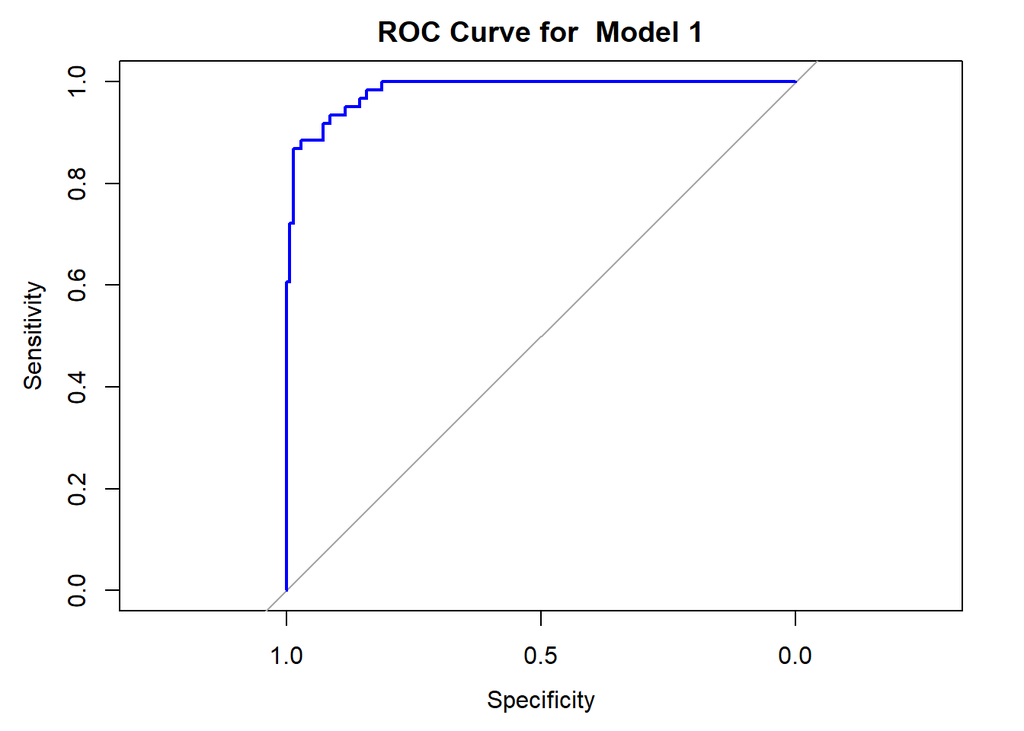

```r
# Plot ROC curve
plot(roc_curve, main = paste("ROC Curve for ", model_name), col = "blue", lwd = 2)
```

```r
# Calculate Precision and Recall on the test dataset
precision_test = cm_test$byClass["Pos Pred Value"]
recall_test = cm_test$byClass["Sensitivity"]

# Print Precision and Recall
print(paste("Final Model (", model_name, ") Test Precision: = ", round(precision_test, 3), sep = ""))
```

```
[1] "Final Model (Model 1) Test Precision: = 0.949"
```

```r
print(paste("Final Model (", model_name, ") Test Recall: = ", round(recall_test, 3), sep = ""))
```

```
[1] "Final Model (Model 1) Test Recall: = 0.935"
```

## Final Model Metrics on Complete Dataset:

```r
# Fit the final model (Model 1) on the complete dataset (imp_data)
M01 <- glm(Default ~ Checking_amount + Term + Credit_score + Car_loan + Personal_loan + Home_loan + Saving_amount + Age,
            family = binomial, data = imp_data)

print(summary(M01))
```

```
Call:
glm(formula = Default ~ Checking_amount + Term + Credit_score +
    Car_loan + Personal_loan + Home_loan + Saving_amount + Age,
    family = binomial, data = imp_data)

Coefficients:
                  Estimate Std. Error z value Pr(>|z|)
(Intercept)     41.9778438  3.8814265  10.815  < 2e-16 ***
Checking_amount -0.0051535  0.0006708  -7.683 1.56e-14 ***
Term             0.1629383  0.0508577   3.204 0.001356 **
Credit_score    -0.0110925  0.0020449  -5.425 5.81e-08 ***
Car_loan1       -1.0239087  0.5438864  -1.883 0.059758 .
Personal_loan1  -1.7959774  0.5380510  -3.338 0.000844 ***
Home_loan1      -3.8968028  0.8735297  -4.461 8.16e-06 ***
Saving_amount   -0.0047608  0.0005985  -7.954 1.80e-15 ***
Age             -0.6586917  0.0642929 -10.245  < 2e-16 ***
---
Signif. codes:  0 '***' 0.001 '**' 0.01 '*' 0.05 '.' 0.1 ' ' 1

(Dispersion parameter for binomial family taken to be 1)

    Null deviance: 1221.73  on 999  degrees of freedom
Residual deviance:  304.19  on 991  degrees of freedom
AIC: 322.19

Number of Fisher Scoring iterations: 7
```

```r
# Predict probabilities for the complete dataset
pred_probs <- predict(M01, newdata = imp_data, type = "response")

# Define a range of thresholds to evaluate
thresholds <- seq(0.1, 0.9, by = 0.05)

# Initialize a vector to store F1-Scores for each threshold
f1_scores <- numeric(length(thresholds))

# Loop over thresholds to calculate F1-Score at each threshold
for (i in 1:length(thresholds)) {
  threshold <- thresholds[i]

  # Convert probabilities to binary predictions based on threshold
  pred_labels <- ifelse(pred_probs > threshold, 1, 0)

  # Calculate confusion matrix for the current threshold
  cm <- confusionMatrix(factor(pred_labels), factor(imp_data$Default))

  # Extract F1-Score from the confusion matrix
  f1_scores[i] <- cm$byClass["F1"]
}

# Find the threshold that gives the highest F1-Score
optimal_threshold_index <- which.max(f1_scores)
optimal_threshold <- thresholds[optimal_threshold_index]

# Print the optimal threshold based on F1-Score
cat("Optimal Threshold based on F1-Score: ", optimal_threshold, "\n")
```

```
Optimal Threshold based on F1-Score:  0.35
```

```r
# Now, predict using the optimal threshold
pred_labels_optimal <- ifelse(pred_probs > optimal_threshold, 1, 0)

# Calculate and print the final F1-Score, Precision, Recall, and AUC at the optimal threshold
cm_optimal <- confusionMatrix(factor(pred_labels_optimal), factor(imp_data$Default))
test_f1 <- cm_optimal$byClass["F1"]
precision_optimal <- cm_optimal$byClass["Pos Pred Value"]
recall_optimal <- cm_optimal$byClass["Sensitivity"]

# AUC
roc_curve_optimal <- roc(imp_data$Default, pred_probs)
auc_value_optimal <- auc(roc_curve_optimal)

# Print final metrics
cat("Optimal Model Test F1-Score: ", round(test_f1, 3), "\n")
```

```
Optimal Model Test F1-Score:  0.955
```

```r
cat("Optimal Model Test Precision: ", round(precision_optimal, 3), "\n")
```

```
Optimal Model Test Precision:  0.962
```

```r
cat("Optimal Model Test Recall: ", round(recall_optimal, 3), "\n")
```

```
Optimal Model Test Recall:  0.947
```

```r
cat("Optimal Model Test AUC: ", round(auc_value_optimal, 3), "\n")
```

```
Optimal Model Test AUC:  0.983
```

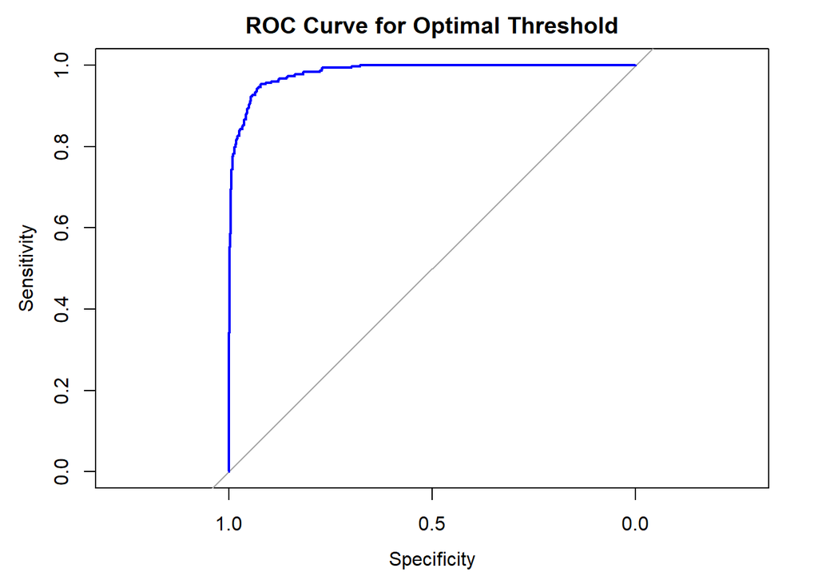

```r
# Plot the ROC curve for the optimal threshold
plot(roc_curve_optimal, main = "ROC Curve for Optimal Threshold", col = "blue", lwd = 2)
```

### Recommendations:

Model Deployment: Given the performance of Model 1, it is recommended to deploy this model in a production environment for predicting loan defaults. The model’s high AUC, F1-Score, and Precision make it reliable for real-world applications, where the cost of mis-classifying a defaulted loan is high.

Threshold Adjustment: It’s recommended to continually evaluate and adjust the decision threshold based on the financial institution’s risk appetite. While the optimal threshold of 0.35 is suitable for balancing Precision and Recall, it may be adjusted in the future depending on business needs. For example, if the institution wants to minimize false positives (i.e., rejecting loans that do not default), the threshold can be increased. Conversely, if minimizing missed defaults is a higher priority, the threshold may be decreased.

Model Monitoring and Updating: While Model 1 performs well, it is important to monitor its performance over time, as patterns of loan defaults may change with evolving economic conditions or borrower behaviors. Periodic model retraining using new data will ensure that the model remains relevant and continues to perform well in predicting loan defaults.

Consider Other Features: As the model’s performance is based on a set of predefined features, it may be worth exploring additional features (such as external economic factors or borrower transaction history) to further improve prediction accuracy. Additional feature engineering and testing can be done to enhance the model’s robustness.